# The Effect of the Method of Cutting on the Moisture Content of Samples from Tree Branches

Hyun Jii Cho

Kirusanth Poopalasingam

## Problem

The xylem elements, which transport the water in the branch, are under tension. Cutting the branch on one end will result the tension to be released on that end and cause the removal of water. On the other hand, cutting them on both ends will result the tension to be reliefed on both ends and result in lesser water loss.

The aim is to find the optimal method in order to minimize the water loss during the cut. The original question posed by the study was if there is a difference in the moisture content between adjacent samples of the same branch.

## Exploratory Analysis

First, we will have briefly analyze the dataset to get some insights into how the different factors may affect the moisture content in branches.

#### Data Format

Data extract

| Species | Branch | Location | TranspirationType | Moisture |
| --- | --- | --- | --- | --- |
| LP | 1 | Central | Rapid | 1304 |
| LP | 1 | Distal | Rapid | 1343 |
| LP | 1 | Proximal | Rapid | 1252 |
| LP | 1 | Central | Slow | 1269 |
| LP | 1 | Distal | Slow | 1320 |
| LP | 1 | Proximal | Slow | 1218 |

The data contains the moisture content measurement for each species, location and transpiration type. Five samples were taken for each combination.

#### Means for each combination of **species**, **location**, **transpiration type**

|  | Central | Distal | Proximal | Central | Distal | Proximal |
| --- | --- | --- | --- | --- | --- | --- |
| LP | 126.26 | 125.76 | 119.60 | 134.56 | 131.76 | 119.28 |
| RG | 138.40 | 111.24 | 111.50 | 101.60 | 107.04 | 103.34 |
| SP | 112.72 | 114.60 | 97.14 | 86.26 | 86.70 | 83.74 |
| YP | 135.08 | 120.10 | 121.06 | 117.18 | 117.84 | 106.60 |

## Interactions

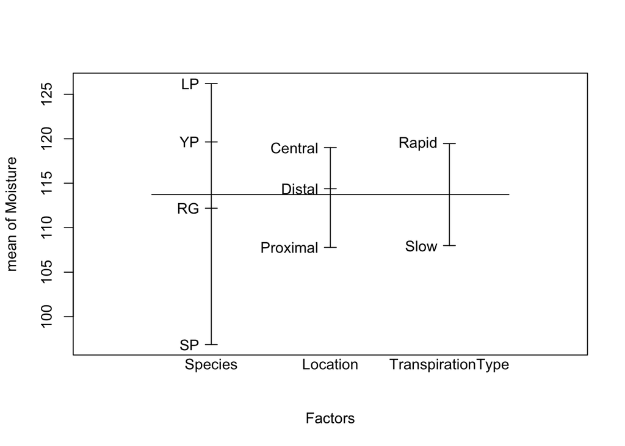

Plot of univariate factor effects on Moisture content variable. The mean of the moisture content seems to change with all the factors, Species, Location, Transpiration type. It would be interesting to also see whether different combinations of the levels of the factors different influence the moisture content of branches. For example we can see whether a specific species, combined with a specific level of Transpiration type affects the moisture content by observing the two-way interaction plot between pairs of factors.

##### ANOVA Models

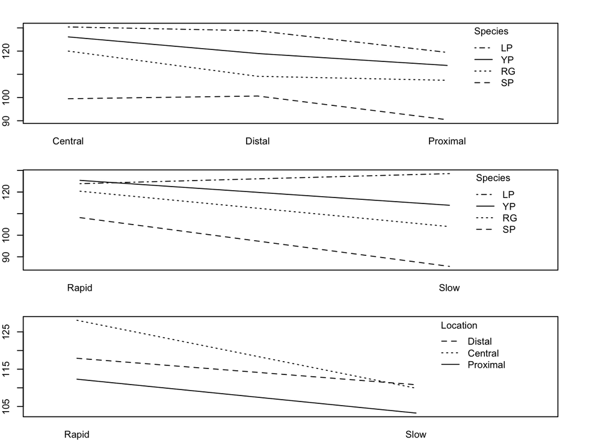

Plots of two-way interaction effects of factors on the moisture content variable. Above, we observe that there may be an interaction between transpiration type and species, such that the species may affect the moisture content differently based on whether the transpiration type is rapid or slow.